# Workshop description

## Aims

This workshop will:

1. Introduce you to the TCGA (The Cancer Genome Atlas) data available at the NCI's Genomic Data Commons (GDC).
2. Demonstrate how to access and import TCGA data using the R/Bioconductor package TCGAbiolinks [@colaprico2015tcgabiolinks].
3. Provide instruction to visualize copy number alteration and mutation data using the R/Bioconductor package maftools.

## Useful links

- the NCI's Genomic Data Commons (GDC): https://gdc.cancer.gov/.
- TCGAbiolinks package: http://bioconductor.org/packages/TCGAbiolinks/
- maftools package: http://bioconductor.org/packages/maftools/

## R/Bioconductor packages used

- [TCGAbiolinks](http://bioconductor.org/packages/TCGAbiolinks/)
- [MultiAssayExperiment](http://bioconductor.org/packages/MultiAssayExperiment/)
- [maftools](http://bioconductor.org/packages/maftools/)
- [ComplexHeatmap](http://bioconductor.org/packages/ComplexHeatmap/)

## Pre-requisites

- Basic knowledge of R syntax
- Understand the pipe operator ("%>%") (help material https://r4ds.had.co.nz/pipes.html)
- Understand the SummarizedExperiment data structure (help material http://bioconductor.org/packages/SummarizedExperiment/)

# Introduction

## Understanding GDC (genomics data common portal)

In this workshop we will access (The Cancer Genome Atlas) data available at the NCI's Genomic Data Commons (GDC). Before we start, it is important to know that the data is deposit in two different databases:

- The legacy archive (https://portal.gdc.cancer.gov/legacy-archive/search/f) which contains unharmonized legacy data from repositories that predate the GDC (e.g. CGHub). Also, legacy data is not actively maintained, processed, or harmonized by the GDC (Source: https://docs.gdc.cancer.gov/Data_Portal/Users_Guide/Legacy_Archive/)
- Harmonized database (https://portal.gdc.cancer.gov/) which contains data from many cancer projects processed using standardized pipelines and the reference genome GRCh38 (hg38). This gives the advantage of analyzing multiple cancer types or the same cancer type across multiple projects. You can find more information about the pipelines supporting data harmonization at https://gdc.cancer.gov/about-data/gdc-data-harmonization and at https://docs.gdc.cancer.gov/Encyclopedia/pages/Harmonized_Data/.

An overview of the web portal is available at https://docs.gdc.cancer.gov/Data_Portal/Users_Guide/Getting_Started/.

Also, a more in-depth comparison between the legacy and Harmonized data was recently published:

- Gao, Galen F., et al. “Before and After: Comparison of Legacy and Harmonized TCGA Genomic Data Commons’ Data.” Cell systems 9.1 (2019): 24-34. (https://doi.org/10.1016/j.cels.2019.06.006)

## Understanding TCGA data

### Data access

GDC provides the data with two access levels:

- Open: includes high level genomic data that is not individually identifiable, as well as most clinical and all biospecimen data elements.
- Controlled: includes individually identifiable data such as low-level genomic sequencing data, germline variants, SNP6 genotype data, and certain clinical data elements

You can find more information about those two levels and how to get access to controlled data at: https://gdc.cancer.gov/access-data/data-access-processes-and-tools.

### TCGA barcode description

You can find a table with all the code and meanings at https://gdc.cancer.gov/resources-tcga-users/tcga-code-tables.

### Data structure

In order to filter the data available in GDC some fields are available such as project (TCGA, TARGET, etc.), data category (Transcriptome Profiling, DNA methylation, Clinical, etc.), data type (Gene Expression Quantification, Isoform Expression Quantification, Methylation Beta Value, etc.), experimental strategy (miRNA-Seq, RNA-Seq, etc.), Workflow Type, platform, access type and others.

In terms of data granularity, a project has data on several categories, each category contains several data types that might have been produced with different workflows, experimental strategy and platforms. In that way, if you select data type "Gene Expression Quantification" the data category will be Transcriptome Profiling.

You can find the entry possibilities for each filter at the repository page of the database at https://portal.gdc.cancer.gov/repository.

## The SummarizedExperiment data structure

Before we start, it is important to know that the R/Bioconductor environment provides a data structure called `SummarizedExperiment`, which was created to handle both samples metadata (age, gender, etc), genomics data (i.e. DNA methylation beta value) and genomics metadata information (chr, start, end, gene symbol) in the same object. You can access samples metadata with `colData` function, genomics data with `assays` and genomics metadata with `rowRanges`.

# Loading required packages

```r
suppressMessages({
    library(TCGAbiolinks)
    library(MultiAssayExperiment)
    library(maftools)
    library(dplyr)
    library(ComplexHeatmap)
})
```

```r
clinical <- GDCquery_clinic("TCGA-COAD")
head(clinical)
```

A data.frame: 6 × 73

| submitter_id <chr> | year_of_diagnosis <int> | classification_of_tumor <chr> | last_known_disease_status <chr> | updated_datetime <chr> | primary_diagnosis <chr> | tumor_stage <chr> | age_at_diagnosis <int> | morphology <chr> | days_to_last_known_disease_status <lgl> | ⋯ | treatments_radiation_treatment_or_therapy <chr> | treatments_radiation_days_to_treatment_start <lgl> | treatments_radiation_treatment_effect <lgl> | treatments_radiation_initial_disease_status <lgl> | treatments_radiation_regimen_or_line_of_therapy <lgl> | treatments_radiation_treatment_anatomic_site <lgl> | treatments_radiation_treatment_outcome <lgl> | treatments_radiation_days_to_treatment_end <lgl> | bcr_patient_barcode <chr> | disease <chr> |
| --- | --- | --- | --- | --- | --- | --- | --- | --- | --- | --- | --- | --- | --- | --- | --- | --- | --- | --- | --- | --- |
| TCGA-3L-AA1B | 2013 | not reported | not reported | 2019-08-08T16:33:45.855164-05:00 | Adenocarcinoma, NOS | stage i | 22379 | 8140/3 | NA | ⋯ | no | NA | NA | NA | NA | NA | NA | NA | TCGA-3L-AA1B | COAD |
| TCGA-4N-A93T | 2013 | not reported | not reported | 2019-08-08T16:33:45.855164-05:00 | Adenocarcinoma, NOS | stage iiib | 24523 | 8140/3 | NA | ⋯ | no | NA | NA | NA | NA | NA | NA | NA | TCGA-4N-A93T | COAD |
| TCGA-4T-AA8H | 2013 | not reported | not reported | 2019-08-08T16:33:45.855164-05:00 | Mucinous adenocarcinoma | stage iia | 15494 | 8480/3 | NA | ⋯ | no | NA | NA | NA | NA | NA | NA | NA | TCGA-4T-AA8H | COAD |
| TCGA-5M-AAT4 | 2009 | not reported | not reported | 2019-08-08T16:33:45.855164-05:00 | Adenocarcinoma, NOS | stage iv | 27095 | 8140/3 | NA | ⋯ | no | NA | NA | NA | NA | NA | NA | NA | TCGA-5M-AAT4 | COAD |
| TCGA-5M-AAT6 | 2009 | not reported | not reported | 2019-08-08T16:33:45.855164-05:00 | Adenocarcinoma, NOS | stage iv | 14852 | 8140/3 | NA | ⋯ | no | NA | NA | NA | NA | NA | NA | NA | TCGA-5M-AAT6 | COAD |
| TCGA-5M-AATE | 2011 | not reported | not reported | 2019-08-08T16:33:45.855164-05:00 | Adenocarcinoma, NOS | stage iia | 27870 | 8140/3 | NA | ⋯ | no | NA | NA | NA | NA | NA | NA | NA | TCGA-5M-AATE | COAD |

```r
query <- GDCquery(project = "TCGA-ACC",
                  data.category = "Clinical",
                  data.type = "Clinical Supplement",
                  data.format = "BCR Biotab")
GDCdownload(query)
clinical.BCRtab.all <- GDCprepare(query)
names(clinical.BCRtab.all)
```

[output not shown]

1. 'clinical_radiation_acc'

2. 'clinical_drug_acc'

3. 'clinical_follow_up_v4.0_acc'

4. 'clinical_omf_v4.0_acc'

5. 'clinical_patient_acc'

6. 'clinical_nte_acc'

7. 'clinical_follow_up_v4.0_nte_acc'

```r
clinical.BCRtab.all$clinical_drug_acc  %>%
  head  %>%
  as.data.frame
```

A data.frame: 6 × 28

| bcr_patient_uuid <chr> | bcr_patient_barcode <chr> | bcr_drug_barcode <chr> | bcr_drug_uuid <chr> | form_completion_date <chr> | pharmaceutical_therapy_drug_name <chr> | clinical_trial_drug_classification <chr> | pharmaceutical_therapy_type <chr> | pharmaceutical_tx_started_days_to <chr> | pharmaceutical_tx_ongoing_indicator <chr> | ⋯ | regimen_indication <chr> | regimen_indication_notes <chr> | regimen_number <chr> | route_of_administration <chr> | stem_cell_transplantation <chr> | stem_cell_transplantation_type <chr> | therapy_type_notes <chr> | total_dose <chr> | total_dose_units <chr> | tx_on_clinical_trial <chr> |
| --- | --- | --- | --- | --- | --- | --- | --- | --- | --- | --- | --- | --- | --- | --- | --- | --- | --- | --- | --- | --- |
| bcr_patient_uuid | bcr_patient_barcode | bcr_drug_barcode | bcr_drug_uuid | form_completion_date | drug_name | clinical_trail_drug_classification | therapy_type | days_to_drug_therapy_start | therapy_ongoing | ⋯ | regimen_indication | regimen_indication_notes | regimen_number | route_of_administration | stem_cell_transplantation | stem_cell_transplantation_type | therapy_type_notes | total_dose | total_dose_units | tx_on_clinical_trial |
| CDE_ID: | CDE_ID:2003301 | CDE_ID: | CDE_ID: | CDE_ID: | CDE_ID:2975232 | CDE_ID:3378323 | CDE_ID:2793530 | CDE_ID:3392465 | CDE_ID:3103479 | ⋯ | CDE_ID:2793511 | CDE_ID:2793516 | CDE_ID:2744948 | CDE_ID:2003586 | CDE_ID:3090688 | CDE_ID:2730901 | CDE_ID:2001762 | CDE_ID:1515 | CDE_ID:3088785 | CDE_ID:3925111 |
| FB54458D-C373-46C2-841E-82663E13EFAA | TCGA-OR-A5JM | TCGA-OR-A5JM-D49539 | B4F66718-B197-4EFB-AF9B-380B238BF6B5 | 2013-10-3 | sunitinib | [Not Available] | Targeted Molecular therapy | 378 | NO | ⋯ | [Not Available] | [Not Applicable] | [Not Available] | [Not Available] | [Not Available] | [Not Available] | [Not Available] | [Not Available] | [Not Available] | NO |
| FB54458D-C373-46C2-841E-82663E13EFAA | TCGA-OR-A5JM | TCGA-OR-A5JM-D49540 | 2B5DD32A-1F38-4899-A90F-77C16B1F900E | 2013-10-3 | ketoconazole | [Not Available] | Targeted Molecular therapy | 378 | NO | ⋯ | [Not Available] | [Not Applicable] | [Not Available] | [Not Available] | [Not Available] | [Not Available] | [Not Available] | [Not Available] | [Not Available] | NO |
| 344F7EA4-2BD4-4F2D-89F2-9FC7F572A3D6 | TCGA-OR-A5JY | TCGA-OR-A5JY-D48310 | 1125569B-151B-4740-A864-9F8BFC63E2B4 | 2013-9-11 | xeloda | [Not Available] | Chemotherapy | 78 | NO | ⋯ | [Not Available] | [Not Applicable] | [Not Available] | [Not Available] | [Not Available] | [Not Available] | [Not Available] | [Not Available] | [Not Available] | NO |
| 6D980941-219E-40A0-9B41-E84C3FB0BD1A | TCGA-OR-A5K2 | TCGA-OR-A5K2-D48215 | 3C5B0FF6-2A7C-456E-8662-D38484AA7F3C | 2013-9-10 | Adriamycin | [Not Available] | Chemotherapy | 118 | NO | ⋯ | [Not Available] | [Not Applicable] | [Not Available] | [Not Available] | [Not Available] | [Not Available] | [Not Available] | [Not Available] | [Not Available] | NO |

## RNA-Seq data

The RNA-Seq pipeline produces raw counts, FPKM and FPKM-UQ quantifications and is described at https://docs.gdc.cancer.gov/Data/Bioinformatics_Pipelines/Expression_mRNA_Pipeline/.

The following options are used to search mRNA results using TCGAbiolinks:

- data.category: "Transcriptome Profiling"
- data.type: "Gene Expression Quantification"
- workflow.type: "HTSeq - Counts", "HTSeq - FPKM", "HTSeq - FPKM-UQ"

Here is the example to download the raw counts, which can be used with DESeq2 (http://bioconductor.org/packages/DESeq2/) for differential expression analysis.

```r
query.exp.hg38 <- GDCquery(project = "TCGA-GBM",
                  data.category = "Transcriptome Profiling",
                  data.type = "Gene Expression Quantification",
                  workflow.type = "HTSeq - Counts",
                  barcode =  c("TCGA-14-0736-02A-01R-2005-01", "TCGA-06-0211-02A-02R-2005-01"))
GDCdownload(query.exp.hg38)
raw.counts <- GDCprepare(query = query.exp.hg38, summarizedExperiment = FALSE)
```

[output not shown]

```
|====================================================|100%                      Completed after 1 s
```

```r
head(raw.counts)
```

A tibble: 6 × 3

| X1 <chr> | TCGA-14-0736-02A-01R-2005-01 <dbl> | TCGA-06-0211-02A-02R-2005-01 <dbl> |
| --- | --- | --- |
| ENSG00000000003.13 | 4282 | 3853 |
| ENSG00000000005.5 | 34 | 8 |
| ENSG00000000419.11 | 899 | 1785 |
| ENSG00000000457.12 | 293 | 551 |
| ENSG00000000460.15 | 143 | 378 |
| ENSG00000000938.11 | 286 | 683 |

```r
query.exp.hg38 <- GDCquery(project = "TCGA-GBM",
                  data.category = "Transcriptome Profiling",
                  data.type = "Gene Expression Quantification",
                  workflow.type = "HTSeq - FPKM-UQ",
                  barcode =  c("TCGA-14-0736-02A-01R-2005-01", "TCGA-06-0211-02A-02R-2005-01"))
GDCdownload(query.exp.hg38)
fpkm.uq.counts <- GDCprepare(query = query.exp.hg38, summarizedExperiment = FALSE)
```

[output not shown]

```
|====================================================|100%                      Completed after 0 s
```

```r
head(fpkm.uq.counts)
```

A tibble: 6 × 3

| X1 <chr> | TCGA-14-0736-02A-01R-2005-01 <dbl> | TCGA-06-0211-02A-02R-2005-01 <dbl> |
| --- | --- | --- |
| ENSG00000242268.2 | 1532.591 | 3517.609 |
| ENSG00000270112.3 | 4253.036 | 4978.410 |
| ENSG00000167578.15 | 261186.594 | 135247.024 |
| ENSG00000273842.1 | 0.000 | 0.000 |
| ENSG00000078237.5 | 224251.000 | 180269.615 |
| ENSG00000146083.10 | 117080.711 | 197064.420 |

## Mutation

1. Use `GDCquery_Maf` which will download MAF aligned against hg38.

This example will download MAF (mutation annotation files) for variant calling pipeline muse. Pipelines options are: `muse`, `varscan2`, `somaticsniper`, `mutect`. For more information please access [GDC docs](https://docs.gdc.cancer.gov/Data/Bioinformatics_Pipelines/DNA_Seq_Variant_Calling_Pipeline/).

You can download the data using TCGAbiolinks `GDCquery_Maf` function.

```r
maf <- GDCquery_Maf("COAD", pipelines = "muse")
maf %>% head %>% as.data.frame
```

[output not shown]

A data.frame: 6 × 120

| Hugo_Symbol <chr> | Entrez_Gene_Id <int> | Center <chr> | NCBI_Build <chr> | Chromosome <chr> | Start_Position <int> | End_Position <int> | Strand <chr> | Variant_Classification <chr> | Variant_Type <chr> | ⋯ | FILTER <chr> | CONTEXT <chr> | src_vcf_id <chr> | tumor_bam_uuid <chr> | normal_bam_uuid <chr> | case_id <chr> | GDC_FILTER <chr> | COSMIC <chr> | MC3_Overlap <chr> | GDC_Validation_Status <chr> |
| --- | --- | --- | --- | --- | --- | --- | --- | --- | --- | --- | --- | --- | --- | --- | --- | --- | --- | --- | --- | --- |
| ATAD3B | 83858 | BCM | GRCh38 | chr1 | 1485803 | 1485803 | + | Nonsense_Mutation | SNP | ⋯ | PASS | TCAGTCGACCC | 9130f121-b7ce-460f-b90c-8e31add6cd10 | 7de9d9e2-c4a4-4311-826f-973cb7987c66 | 861ad835-790a-47ad-8c03-06f7eb7b5710 | 7a70f061-9a6f-408e-a416-7f5295ceba3b | NA | COSM1333470 | True | Unknown |
| PLCH2 | 9651 | BCM | GRCh38 | chr1 | 2487195 | 2487195 | + | Silent | SNP | ⋯ | PASS | AGGAGCCCTGC | 9130f121-b7ce-460f-b90c-8e31add6cd10 | 7de9d9e2-c4a4-4311-826f-973cb7987c66 | 861ad835-790a-47ad-8c03-06f7eb7b5710 | 7a70f061-9a6f-408e-a416-7f5295ceba3b | NA | COSM1340725;COSM1340726 | True | Unknown |
| CHD5 | 26038 | BCM | GRCh38 | chr1 | 6146395 | 6146395 | + | Missense_Mutation | SNP | ⋯ | PASS | AGTTGCGATAC | 9130f121-b7ce-460f-b90c-8e31add6cd10 | 7de9d9e2-c4a4-4311-826f-973cb7987c66 | 861ad835-790a-47ad-8c03-06f7eb7b5710 | 7a70f061-9a6f-408e-a416-7f5295ceba3b | NA | COSM911251 | True | Unknown |
| IFNLR1 | 163702 | BCM | GRCh38 | chr1 | 24159060 | 24159060 | + | Missense_Mutation | SNP | ⋯ | PASS | GGCCCGTGGCA | 9130f121-b7ce-460f-b90c-8e31add6cd10 | 7de9d9e2-c4a4-4311-826f-973cb7987c66 | 861ad835-790a-47ad-8c03-06f7eb7b5710 | 7a70f061-9a6f-408e-a416-7f5295ceba3b | NA | COSM1340840 | True | Unknown |
| YTHDF2 | 51441 | BCM | GRCh38 | chr1 | 28769136 | 28769136 | + | 3'UTR | SNP | ⋯ | PASS | AAAAAAAGAAA | 9130f121-b7ce-460f-b90c-8e31add6cd10 | 7de9d9e2-c4a4-4311-826f-973cb7987c66 | 861ad835-790a-47ad-8c03-06f7eb7b5710 | 7a70f061-9a6f-408e-a416-7f5295ceba3b | NA | NA | True | Unknown |
| LRP8 | 7804 | BCM | GRCh38 | chr1 | 53289634 | 53289634 | + | Silent | SNP | ⋯ | PASS | CGTTCGTGGAT | 9130f121-b7ce-460f-b90c-8e31add6cd10 | 7de9d9e2-c4a4-4311-826f-973cb7987c66 | 861ad835-790a-47ad-8c03-06f7eb7b5710 | 7a70f061-9a6f-408e-a416-7f5295ceba3b | NA | NA | True | Unknown |

Then visualize the results using the maftools package.

```r
# create maftools input
maftools.input <- maf %>% read.maf
```

```
-Validating
-Silent variants: 77997
-Summarizing
--Mutiple centers found
BCM;WUGSC;WUGSC;BCM;BCM;BI--Possible FLAGS among top ten genes:
  TTN
  MUC16
  SYNE1
  OBSCN
-Processing clinical data
--Missing clinical data
-Finished in 14.3s elapsed (12.8s cpu)
```

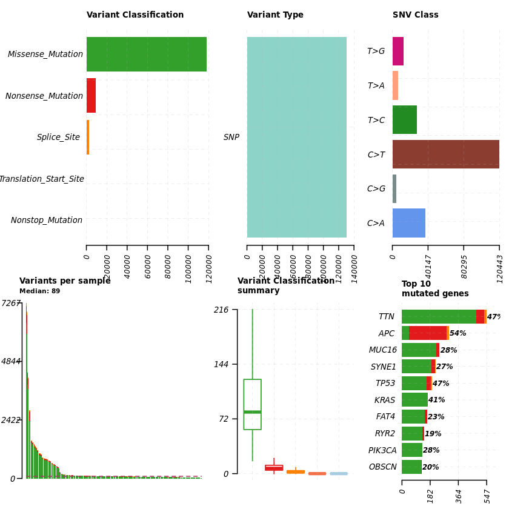

```r
# Check summary
plotmafSummary(maf = maftools.input,
               rmOutlier = TRUE,
               addStat = 'median',
               dashboard = TRUE)
```

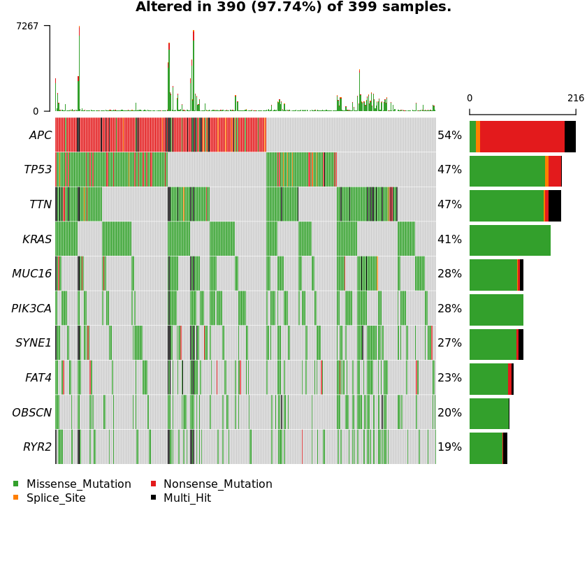

```r
oncoplot(maf = maftools.input,
         top = 10,
         removeNonMutated = TRUE)
```

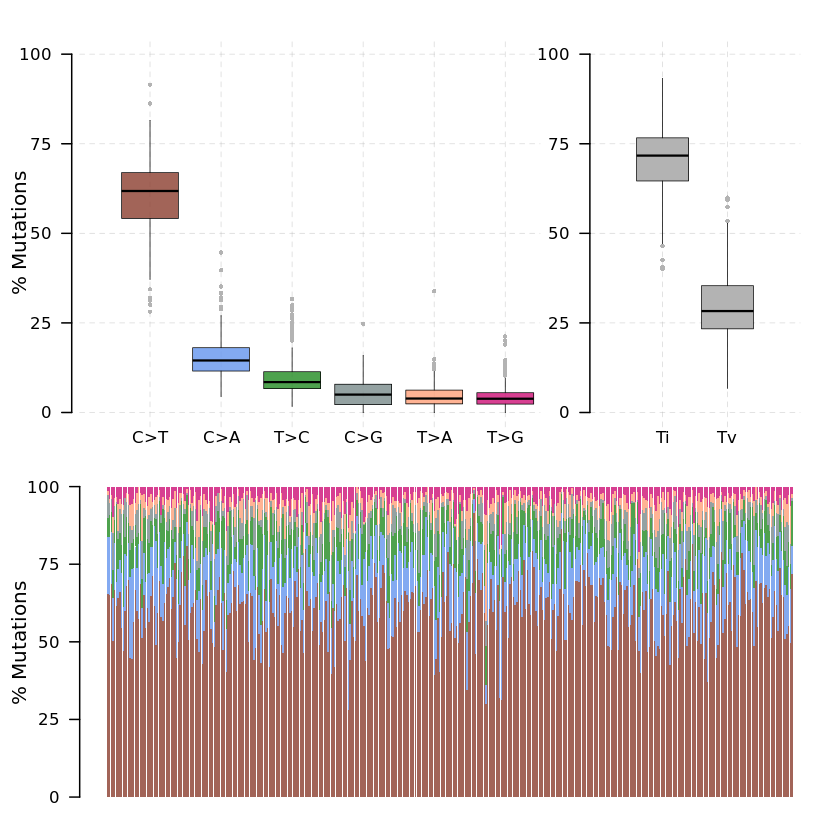

```r
# classifies Single Nucleotide Variants into Transitions and Transversions
titv = titv(maf = maftools.input,
            plot = FALSE,
            useSyn = TRUE)
plotTiTv(res = titv)
```

You can extract sample summary from MAF object.

```r
getSampleSummary(maftools.input) %>% head
```

A data.table: 6 × 7

| Tumor_Sample_Barcode <fct> | Missense_Mutation <int> | Nonsense_Mutation <int> | Nonstop_Mutation <int> | Splice_Site <int> | Translation_Start_Site <int> | total <dbl> |
| --- | --- | --- | --- | --- | --- | --- |
| TCGA-AA-A010-01A-01D-A17O-10 | 6440 | 691 | 5 | 128 | 3 | 7267 |
| TCGA-CA-6717-01A-11D-1835-10 | 5989 | 773 | 8 | 124 | 5 | 6899 |
| TCGA-AZ-4315-01A-01D-1408-10 | 5222 | 536 | 2 | 79 | 2 | 5841 |
| TCGA-AA-3984-01A-02D-1981-10 | 3867 | 475 | 5 | 59 | 0 | 4406 |
| TCGA-AA-A00N-01A-02D-A17O-10 | 3690 | 431 | 4 | 52 | 4 | 4181 |
| TCGA-CK-4951-01A-01D-1408-10 | 3254 | 205 | 6 | 72 | 5 | 3542 |

## Copy number alteration data

The Copy Number Variation Analysis Pipeline is described at https://docs.gdc.cancer.gov/Data/Bioinformatics_Pipelines/CNV_Pipeline/

Numeric focal-level Copy Number Variation (CNV) values were generated with "Masked Copy Number Segment" files from tumor aliquots using GISTIC2 on a project level. Only protein-coding genes were kept, and their numeric CNV values were further thresholded by a noise cutoff of 0.3:

- Genes with focal CNV values smaller than -0.3 are categorized as a "loss" (-1)
- Genes with focal CNV values larger than 0.3 are categorized as a "gain" (+1)
- Genes with focal CNV values between and including -0.3 and 0.3 are categorized as "neutral" (0).

You can access "Gene Level Copy Number Scores" from GISTIC with the code below:

```r
query <- GDCquery(project = "TCGA-GBM",
             data.category = "Copy Number Variation",
             data.type = "Gene Level Copy Number Scores",
             access = "open")
GDCdownload(query)
scores <- GDCprepare(query)
scores[1:5,1:5]
```

[output not shown]

A tibble: 5 × 5

| Gene Symbol <chr> | Gene ID <dbl> | Cytoband <chr> | TCGA-19-1790-01B-01D-1224-01 <dbl> | TCGA-41-2572-01A-01D-1224-01 <dbl> |
| --- | --- | --- | --- | --- |
| ENSG00000008128.21 | 0 | 1p36.33 | 0 | 0 |
| ENSG00000008130.14 | 0 | 1p36.33 | 0 | 0 |
| ENSG00000067606.14 | 0 | 1p36.33 | 0 | 0 |
| ENSG00000078369.16 | 0 | 1p36.33 | 0 | 0 |
| ENSG00000078808.15 | 0 | 1p36.33 | 0 | 0 |

You can visualize the data using the R/Bioconductor package complexHeatmap.

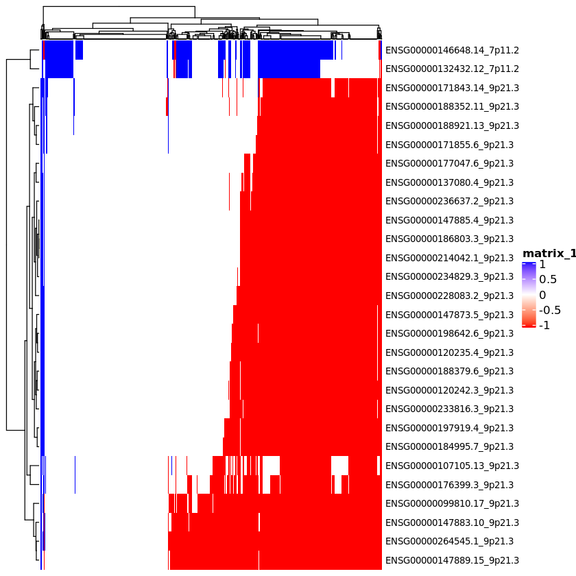

```r
scores.matrix <- scores %>%
  dplyr::select(-c(1:3)) %>%  # Removes metadata from the first 3 columns
  as.matrix

rownames(scores.matrix) <- paste0(scores$`Gene Symbol`,"_",scores$Cytoband)

# gain in more than 200 samples
gain.more.than.twohundred.samples <- which(rowSums(scores.matrix == 1) > 200)

# loss in more than 200 samples
loss.more.than.twohundred.samples <- which(rowSums(scores.matrix == -1) > 200)

lines.selected <- c(gain.more.than.twohundred.samples,loss.more.than.twohundred.samples)

Heatmap(scores.matrix[lines.selected,],
        show_column_names = FALSE,
        show_row_names = TRUE,
        row_names_gp = gpar(fontsize = 8),
        col = circlize::colorRamp2(c(-1,0,1), colors = c("red","white","blue")))
```

## DNA methylation data

The processed DNA methylation data measure the level of methylation at known CpG sites as beta values, calculated from array intensities (Level 2 data) as Beta = $M/(M+U)$ [@zhou2017comprehensive] which ranges from 0 being unmethylated and 1 fully methylated.

More information about the DNA methylation pipeline is available at https://docs.gdc.cancer.gov/Data/Bioinformatics_Pipelines/Methylation_LO_Pipeline/.

We will download two Glioblastoma (GBM) as a summarizedExperiment object.

```r
query_met.hg38 <- GDCquery(project = "TCGA-GBM",
                           data.category = "DNA Methylation",
                           platform = "Illumina Human Methylation 27",
                           barcode = c("TCGA-02-0116-01A","TCGA-14-3477-01A-01D"))
GDCdownload(query_met.hg38)
data.hg38 <- GDCprepare(query_met.hg38,summarizedExperiment = TRUE)
```

[output not shown]

```
|====================================================|100%                      Completed after 0 s
```

```
Starting to add information to samples
 => Add clinical information to samples
Add FFPE information. More information at:
=> https://cancergenome.nih.gov/cancersselected/biospeccriteria
=> http://gdac.broadinstitute.org/runs/sampleReports/latest/FPPP_FFPE_Cases.html
 => Adding subtype information to samples
gbm subtype information from:doi:10.1016/j.cell.2015.12.028
```

```r
data.hg38
```

```
class: RangedSummarizedExperiment
dim: 27578 2
metadata(1): data_release
assays(1): ''
rownames(27578): cg00000292 cg00002426 ... cg27662877 cg27665659
rowData names(7): Composite.Element.REF Gene_Symbol ... CGI_Coordinate
  Feature_Type
colnames(2): TCGA-02-0116-01A-01D-0199-05 TCGA-14-3477-01A-01D-0915-05
colData names(113): sample patient ...
  subtype_Telomere.length.estimate.in.blood.normal..Kb.
  subtype_Telomere.length.estimate.in.tumor..Kb.
```

You can access the probes information with `rowRanges`.

```r
data.hg38 %>% rowRanges %>% as.data.frame %>% head
```

A data.frame: 6 × 12

|  | seqnames <fct> | start <int> | end <int> | width <int> | strand <fct> | Composite.Element.REF <chr> | Gene_Symbol <chr> | Gene_Type <chr> | Transcript_ID <chr> | Position_to_TSS <chr> | CGI_Coordinate <chr> | Feature_Type <chr> |
| --- | --- | --- | --- | --- | --- | --- | --- | --- | --- | --- | --- | --- |
| cg00000292 | chr16 | 28878779 | 28878780 | 2 | * | cg00000292 | ATP2A1;ATP2A1;ATP2A1;ATP2A1;ATP2A1 | protein_coding;protein_coding;protein_coding;protein_coding;protein_coding | ENST00000357084.6;ENST00000395503.7;ENST00000536376.4;ENST00000562185.4;ENST00000563975.1 | 373;290;-1275;-465;-83 | CGI:chr16:28879633-28880547 | N_Shore |
| cg00002426 | chr3 | 57757816 | 57757817 | 2 | * | cg00002426 | SLMAP;SLMAP;SLMAP;SLMAP;SLMAP;SLMAP | protein_coding;protein_coding;protein_coding;protein_coding;protein_coding;protein_coding | ENST00000295951.6;ENST00000295952.6;ENST00000383718.6;ENST00000428312.4;ENST00000449503.5;ENST00000467901.1 | 1585;368;261;257;257;514 | CGI:chr3:57756198-57757263 | S_Shore |
| cg00003994 | chr7 | 15686237 | 15686238 | 2 | * | cg00003994 | MEOX2 | protein_coding | ENST00000262041.5 | 576 | CGI:chr7:16399497-16399700 | . |
| cg00005847 | chr2 | 176164345 | 176164346 | 2 | * | cg00005847 | AC009336.19;HOXD3;HOXD3;HOXD3;RP11-387A1.5 | protein_coding;protein_coding;protein_coding;protein_coding;antisense | ENST00000468418.4;ENST00000249440.4;ENST00000410016.4;ENST00000432796.2;ENST00000608941.1 | 13259;267;3453;27387;1372 | CGI:chr2:176164685-176165509 | N_Shore |
| cg00006414 | chr7 | 149125745 | 149125746 | 2 | * | cg00006414 | RN7SL521P;ZNF398;ZNF425;ZNF425 | misc_RNA;protein_coding;protein_coding;protein_coding | ENST00000488398.3;ENST00000426851.5;ENST00000378061.5;ENST00000483014.1 | 242;-672;602;562 | CGI:chr7:149126122-149127136 | N_Shore |
| cg00007981 | chr11 | 94129428 | 94129429 | 2 | * | cg00007981 | PANX1;PANX1 | protein_coding;protein_coding | ENST00000227638.6;ENST00000436171.2 | 499;498 | CGI:chr11:94128394-94129607 | Island |

You can access the samples metadata with `colData`.

```r
data.hg38 %>% colData %>% as.data.frame
```

A data.frame: 2 × 113

|  | sample <chr> | patient <chr> | barcode <chr> | shortLetterCode <chr> | definition <chr> | year_of_diagnosis <int> | classification_of_tumor <chr> | last_known_disease_status <chr> | updated_datetime.x <chr> | primary_diagnosis <chr> | ⋯ | subtype_Transcriptome.Subtype <fct> | subtype_Pan.Glioma.RNA.Expression.Cluster <fct> | subtype_IDH.specific.RNA.Expression.Cluster <fct> | subtype_Pan.Glioma.DNA.Methylation.Cluster <fct> | subtype_IDH.specific.DNA.Methylation.Cluster <fct> | subtype_Supervised.DNA.Methylation.Cluster <fct> | subtype_Random.Forest.Sturm.Cluster <fct> | subtype_RPPA.cluster <fct> | subtype_Telomere.length.estimate.in.blood.normal..Kb. <dbl> | subtype_Telomere.length.estimate.in.tumor..Kb. <dbl> |
| --- | --- | --- | --- | --- | --- | --- | --- | --- | --- | --- | --- | --- | --- | --- | --- | --- | --- | --- | --- | --- | --- |
| TCGA-02-0116-01A-01D-0199-05 | TCGA-02-0116-01A | TCGA-02-0116 | TCGA-02-0116-01A-01D-0199-05 | TP | Primary solid Tumor | 2003 | not reported | not reported | 2019-08-08T16:40:20.353826-05:00 | Glioblastoma | ⋯ | NA | LGr4 | NA | LGm4 | IDHwt-K1 | Classic-like | NA | K1 | NA | NA |
| TCGA-14-3477-01A-01D-0915-05 | TCGA-14-3477-01A | TCGA-14-3477 | TCGA-14-3477-01A-01D-0915-05 | TP | Primary solid Tumor | 2009 | not reported | not reported | 2019-08-08T16:42:28.969386-05:00 | Glioblastoma | ⋯ | PN | LGr1 | NA | LGm6 | IDHwt-K3 | LGm6-GBM | NA | NA | NA | NA |

You can access the DNA methylation levels with `assay`.

```r
data.hg38 %>% assay %>% head %>% as.data.frame
```

A data.frame: 6 × 2

|  | TCGA-02-0116-01A-01D-0199-05 <dbl> | TCGA-14-3477-01A-01D-0915-05 <dbl> |
| --- | --- | --- |
| cg00000292 | 0.78495250 | 0.11314067 |
| cg00002426 | 0.06028424 | 0.02843910 |
| cg00003994 | 0.04285454 | 0.24091388 |
| cg00005847 | 0.62490042 | 0.07579907 |
| cg00006414 | NA | NA |
| cg00007981 | 0.04020515 | 0.03530111 |

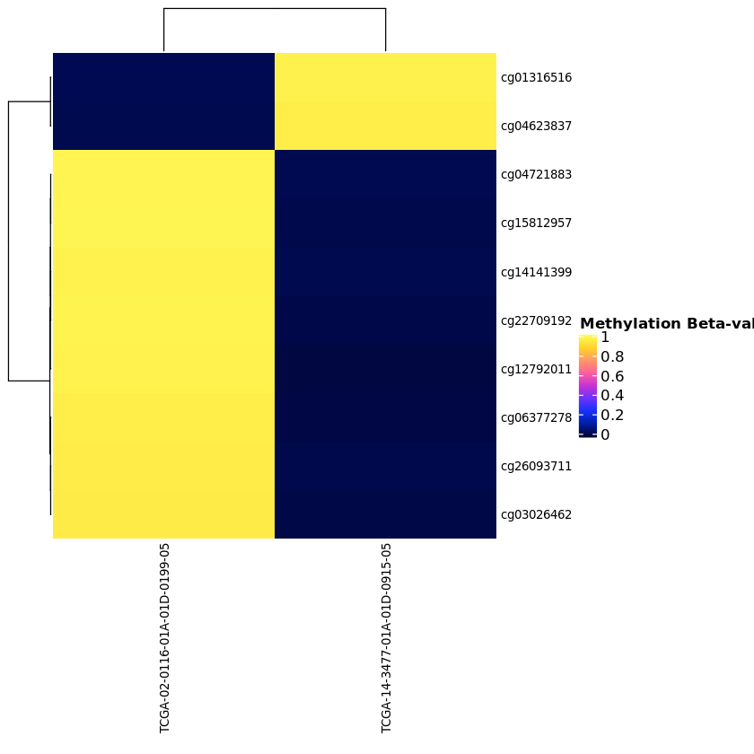

```r
# plot 10 most variable probes
data.hg38 %>%
  assay %>%
  rowVars %>%
  order(decreasing = TRUE) %>%
  head(10) -> idx

pal_methylation <- colorRampPalette(c("#000436",
                                      "#021EA9",
                                      "#1632FB",
                                      "#6E34FC",
                                      "#C732D5",
                                      "#FD619D",
                                      "#FF9965",
                                      "#FFD32B",
                                      "#FFFC5A"))(100)

Heatmap(assay(data.hg38)[idx,],
        show_column_names = TRUE,
        show_row_names = TRUE,
         name = "Methylation Beta-value",
         row_names_gp = gpar(fontsize = 8),
         column_names_gp = gpar(fontsize = 8),
        col = circlize::colorRamp2(seq(0, 1, by = 1/99), pal_methylation))
```

## ATAC-Seq data

Please, check our ATAC-seq Workshop: http://rpubs.com/tiagochst/atac_seq_workshop

# Workshop materials

## Source code

All source code used to produce the workshops are available at https://github.com/tiagochst/ELMER_workshop_2019.

## Workshops HTMLs

- ELMER data Workshop HTML: http://rpubs.com/tiagochst/elmer-data-workshop-2019
- ELMER analysis Workshop HTML: http://rpubs.com/tiagochst/ELMER_workshop
- ATAC-seq Workshop HTML: http://rpubs.com/tiagochst/atac_seq_workshop

## Workshop videos

We have a set of recorded videos, explaining some of the workshops.

- All videos playlist: https://www.youtube.com/playlist?list=PLoDzAKMJh15kNpCSIxpSuZgksZbJNfmMt
- ELMER algorithm: https://youtu.be/PzC31K9vfu0
- ELMER data: https://youtu.be/R00wG--tGo8
- ELMER analysis part1: https://youtu.be/bcd4uyxrZCw
- ELMER analysis part2: https://youtu.be/vcJ_DSCt4Mo
- ELMER summarizing several analyses: https://youtu.be/moLeik7JjLk
- ATAC-Seq workshop: https://youtu.be/3ftZecz0lU4